title: “Impact of PM2.5 Exposure on Low Birth Weight in Ulaanbaatar from 2016–2025” author: “Ahmadi, Barua, Bhuyan, Karayel” date: “2025-04-30” output: pdf_document: toc: true toc_depth: 2 number_sections: true latex_engine: xelatex fig_caption: true includes: in_header: lof-lot.tex —

# Introduction

## Rationale and Research Questions

Air pollution, particularly PM2.5, remains a significant public health concern in Ulaanbaatar. This project examines whether exposure to elevated PM2.5 concentrations during pregnancy is associated with an increased risk of low birth weight (LBW) among newborns between 2016 and 2025.

### Research Questions

- What are the seasonal and long-term trends in PM2.5 concentrations in Ulaanbaatar?
- Is there a measurable association between PM2.5 exposure levels and low birth weight rates?
- Does the timing of PM2.5 exposure during pregnancy (examined through lagged exposure models) influence birth outcomes?

# Dataset Information

## Data Structure

- **PM2.5 data**:
  - Combined annual CSV files across multiple years.
  - Replaced invalid `-999` entries with `NA`.
  - Aggregated hourly readings into daily and monthly averages to align with birth record reporting.
- **Birth outcomes data**:
  - Reshaped from wide format to long format for time series analysis.
  - Merged live births and low birth weight counts into a unified dataset.
- **Final merged dataset**:
  - Monthly PM2.5 exposure data was linked with corresponding monthly birth outcome data by date.

| Dataset | Key Variables | Notes |
| --- | --- | --- |
| PM2.5 Pollution | DateTime, Raw Concentration, AQI | Aggregated to monthly averages |
| Birth Outcomes | Date, Aimag, Low Birth Weight count, Live Births | Cleaned and merged records |

# Data Wrangling and Cleaning

## PM2.5 Data Analysis

```r
#No we load and prepare the raw PM2.5 and birth outcome datasets as described previously.

# Defining file paths for PM2.5 data
years <- 2015:2025
pm25_files <- paste0("Data/Raw/Ulaanbaatar_PM2.5_", years, "_YTD.csv")
names(pm25_files) <- years

# Reading and binding all PM2.5 files
pm25_all <- map_dfr(pm25_files, ~ read_csv(.x, show_col_types = FALSE))

# Cleaning and converting -999 to NA
pm25_all <- pm25_all %>%
  mutate(across(where(is.numeric), ~ na_if(., -999))) %>%
  clean_names() %>%
  rename(DateTime = date_lt) %>%
  mutate(
    DateTime = parse_date_time(DateTime, orders = "ymd IMp"),
    Date     = as_date(DateTime)
  )

#We start by analyzing the structure, quality, and time-related aspects of the air pollution data.

# Daily average
pm25_daily <- pm25_all %>%
  group_by(Date) %>%
  summarize(
    raw_conc_daily = mean(raw_conc, na.rm = TRUE),
    aqi_daily = mean(aqi, na.rm = TRUE),
    .groups = "drop"
  )

# Monthly average
pm25_monthly <- pm25_daily %>%
  mutate(Month = floor_date(Date, "month")) %>%
  group_by(Month) %>%
  summarize(
    raw_conc_monthly = mean(raw_conc_daily, na.rm = TRUE),
    aqi_monthly = mean(aqi_daily, na.rm = TRUE),
    .groups = "drop"
  )
```

## Birth Outcome Data Analysis

```r
# Load birth outcome data
birth_weight_low <- read_csv("Data/Raw/BIRTH WEIGTH LOWER THAN 2500 GRAMS.csv")
live_births      <- read_csv("Data/Raw/LIVE BIRTHS.csv")
# Clean numeric columns in live births (in case of commas)
for (col in names(live_births)[-1]) {
  live_births[[col]] <- as.numeric(gsub(",", "",
                                        live_births[[col]]))
}

# Reshape both datasets to long format
birth_weight_long <- birth_weight_low %>%
  pivot_longer(-Aimag,
               names_to = "Month",
               values_to = "Low_Birth_Weight") %>%
  mutate(Month = gsub("^X", "", Month))

live_births_long <- live_births %>%
  pivot_longer(-Aimag,
               names_to = "Month",
               values_to = "Live_Births") %>%
  mutate(Month = gsub("^X", "", Month))

# Merge and finalize
births_merged <- left_join(birth_weight_long,
                           live_births_long,
                           by = c("Aimag", "Month")) %>%
  mutate(Date = ym(Month)) %>%
  select(Aimag,
         Date,
         Low_Birth_Weight,
         Live_Births)
```

# Exploratory Analysis

## PM2.5

### Seasonality

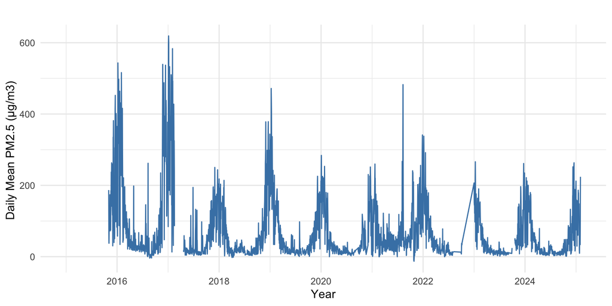

Seasonal Pattern of PM2.5 Concentation in Ulaanbaatar

```r
ggplot(pm25_daily, aes(x = Date,
                       y = raw_conc_daily)) +
  geom_line(color = "steelblue") +
  labs(
    title = "",
    x = "Year",
    y = "Daily Mean PM2.5 (µg/m3) "
  ) +
  theme_minimal()
```

### Missing Data

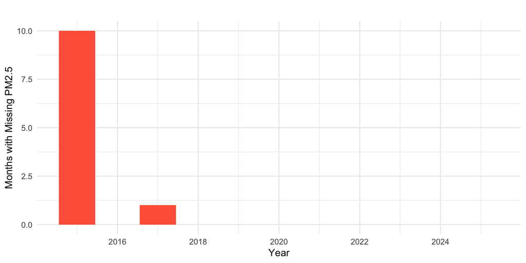

Number of Months with Missing PM2.5 Data

```r
#We evaluate missingness by calculating how many months each year had incomplete PM2.5 daily records.

pm25_yearly_missing <- pm25_monthly %>%
  mutate(Year = year(Month)) %>%
  group_by(Year) %>%
  summarize(
    months_with_missing = sum(is.na(raw_conc_monthly)),
    .groups = "drop"
  )

ggplot(pm25_yearly_missing, aes(x = Year,
                                y = months_with_missing)) +
  geom_col(fill = "tomato") +
  labs(
    title = "",
    x = "Year",
    y = "Months with Missing PM2.5"
  ) +
  theme_minimal()
```

### Outlier Detection

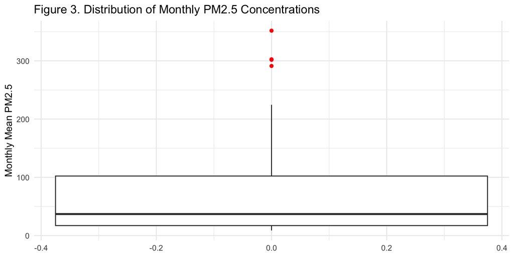

Distribution of Monthly PM2.5 Concentrations

```r
#We also explore the variability of monthly PM2.5 to check for seasonal peaks and outliers.

ggplot(pm25_monthly, aes(y = raw_conc_monthly)) +
  geom_boxplot(outlier.color = "red") +
  labs(
    title = "Figure 3. Distribution of Monthly PM2.5 Concentrations",
    y = "Monthly Mean PM2.5"
  ) +
  theme_minimal()
```

## Merge Exposure and Outcome Data

We link monthly PM2.5 exposure data with corresponding monthly birth outcomes. Therefore, in this section, we merge exposure and outcome datasets, calculate the low birth weight (LBW) rate, and begin preliminary modeling to investigate associations between PM2.5 exposure and birth outcomes.

```r
# Merge datasets by Date
full_data <- births_merged %>%
  left_join(pm25_monthly,
            by = c("Date" = "Month")) %>%
  arrange(Date)
```

To make the comparison and to run the model we have created a new variable called Low Birth Weight Rate

LBW_rate = (Low Birth Weight / Live Births) * 100

```r
full_data <- full_data %>%
  mutate(LBW_rate = 100 * Low_Birth_Weight / Live_Births)
```

## Summary Statistics

```r
summary_stats <- full_data %>%
  summarise(
    Mean_LBW_Rate = mean(LBW_rate, na.rm = TRUE),
    Median_LBW_Rate = median(LBW_rate, na.rm = TRUE),
    Mean_PM25 = mean(raw_conc_monthly, na.rm = TRUE),
    Median_PM25 = median(raw_conc_monthly, na.rm = TRUE)
  )

summary_stats %>%
  kable(caption = "", digits = 2) %>%
  kable_styling(full_width = FALSE)
```

| Mean_LBW_Rate | Median_LBW_Rate | Mean_PM25 | Median_PM25 |
| --- | --- | --- | --- |
| 5.03 | 4.96 | 67.28 | 35.22 |

## Bivariate Visulization

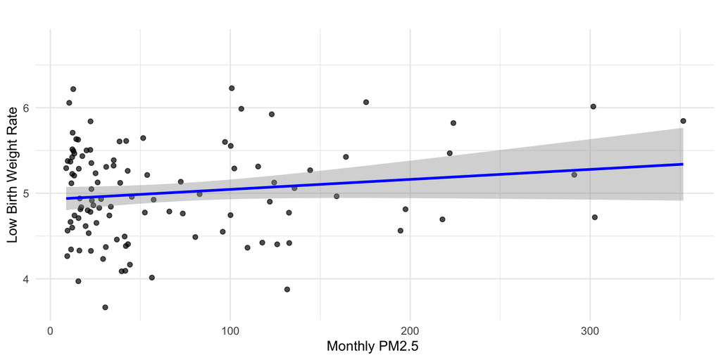

Relationship between Monthly PM2.5 and LBW Rate

```r
ggplot(full_data, aes(x = raw_conc_monthly,
                      y = LBW_rate)) +
  geom_point(alpha = 0.7) +
  geom_smooth(method = "lm",
              se = TRUE,
              color = "blue") +
  labs(
    title = "",
    x = "Monthly PM2.5 ",
    y = "Low Birth Weight Rate"
  ) +
  theme_minimal()
```

# Methods and Models

## Model Fitting

We fit a simple linear regression model at first LBW Rate ~ Monthly PM2.5 Concentration

We started the analysis with a simple linear regression to test the association between monthly PM2.5 concentrations and LBW rates in Ulaanbaatar. This initial model, which regressed LBW rates on same-month PM2.5 levels, produced a weak and statistically non-significant relationship [p = 0.113].

```r
model_simple <- lm(LBW_rate ~ raw_conc_monthly,
                   data = full_data)

tidy(model_simple) %>%
  kable(caption = "Simple Linear Regression", digits = 3) %>%
  kable_styling(full_width = FALSE)
```

Simple Linear Regression

| term | estimate | std.error | statistic | p.value |
| --- | --- | --- | --- | --- |
| (Intercept) | 4.928 | 0.072 | 68.089 | 0.000 |
| raw_conc_monthly | 0.001 | 0.001 | 1.597 | 0.113 |

To account for the possibility that air pollution during pregnancy may affect birth outcomes with a delay, a distributed lag model was applied, incorporating PM2.5 exposures lagged by 0–3 months. However, this approach revealed high multicollinearity among lagged variables (variance inflation factors greater than 8 for some lags), which inflated standard errors and made it difficult to isolate the effect of any single month’s exposure.

```r
# Now We fit a distributed lag linear model:
#LBW Rate ~ PM2.5 exposure in current and previous 3 months

model_data <- full_data %>%
  arrange(Date) %>%
  mutate(
    pm25_lag0 = raw_conc_monthly,
    pm25_lag1 = lag(raw_conc_monthly, 1),
    pm25_lag2 = lag(raw_conc_monthly, 2),
    pm25_lag3 = lag(raw_conc_monthly, 3)
  )
model_lag <- lm(LBW_rate ~ pm25_lag0 + pm25_lag1 + pm25_lag2 + pm25_lag3,
                data = model_data)

tidy(model_lag) %>%
  kable(caption = "Distributed Lag Model", digits = 3) %>%
  kable_styling(full_width = FALSE)
```

Distributed Lag Model

| term | estimate | std.error | statistic | p.value |
| --- | --- | --- | --- | --- |
| (Intercept) | 5.053 | 0.097 | 52.155 | 0.000 |
| pm25_lag0 | -0.001 | 0.002 | -0.369 | 0.713 |
| pm25_lag1 | 0.002 | 0.003 | 0.750 | 0.455 |
| pm25_lag2 | 0.001 | 0.003 | 0.441 | 0.660 |
| pm25_lag3 | -0.003 | 0.002 | -1.742 | 0.085 |

Cumulative exposure models were then constructed by averaging PM2.5 over biologically plausible windows (e.g., 1–2 months and 1–3 months before birth) to capture sustained exposure during critical gestational periods. Despite this, the results remained non-significant, with small coefficients beta = 0.001, high p values [p = 0.158 for 1-2 months, p = 0.390 for 1-3 months]

```r
#Finally, we fit simple models of LBW Rate on cumulative exposures:
cum_model_data <- model_data %>%
  mutate(
    pm25_cum12 = (pm25_lag1 + pm25_lag2) / 2,
    pm25_cum123 = (pm25_lag1 + pm25_lag2 + pm25_lag3) / 3
  )

model_cum12 <- lm(LBW_rate ~ pm25_cum12, data = cum_model_data)
model_cum123 <- lm(LBW_rate ~ pm25_cum123, data = cum_model_data)

bind_rows(
  tidy(model_cum12) %>% mutate(Model = "Cumulative Lag 1-2"),
  tidy(model_cum123) %>% mutate(Model = "Cumulative Lag 1-3")
) %>%
  select(Model, term, estimate, std.error, statistic, p.value) %>%
  kable(caption = "LBW Rate on Cumulative PM2.5 Exposures", digits = 3) %>%
  kable_styling(full_width = FALSE)
```

LBW Rate on Cumulative PM2.5 Exposures

| Model | term | estimate | std.error | statistic | p.value |
| --- | --- | --- | --- | --- | --- |
| Cumulative Lag 1-2 | (Intercept) | 4.944 | 0.080 | 62.183 | 0.000 |
| Cumulative Lag 1-2 | pm25_cum12 | 0.001 | 0.001 | 1.421 | 0.158 |
| Cumulative Lag 1-3 | (Intercept) | 4.985 | 0.085 | 58.483 | 0.000 |
| Cumulative Lag 1-3 | pm25_cum123 | 0.001 | 0.001 | 0.863 | 0.390 |

Both cumulative models show a very small estimated increase in LBW rate (0.001 percentage points) per unit increase in cumulative PM2.5 exposure, but neither result is statistically significant. This suggests that, based on the available data, cumulative PM2.5 exposure in the last 2–3 months of pregnancy is not strongly or consistently associated with changes in LBW rate.

## Result Diagnostics

Now we assess multicollinearity among the lagged PM2.5 variables using VIFs.A VIF greater than 5–10 indicates problematic multicollinearity.

```r
# Calculate VIFs
vif_values <- vif(model_lag)

# Display neatly
vif_values %>%
  as.data.frame() %>%
  rownames_to_column("Predictor") %>%
  rename(VIF = ".") %>%
  kable(caption = "Variance Inflation Factors for Lagged PM2.5 Model", digits = 2) %>%
  kable_styling(full_width = FALSE)
```

Variance Inflation Factors for Lagged PM2.5 Model

| Predictor | VIF |
| --- | --- |
| pm25_lag0 | 4.06 |
| pm25_lag1 | 8.89 |
| pm25_lag2 | 8.08 |
| pm25_lag3 | 3.44 |

Analysis:The high VIF values (especially for lags 1 and 2) suggest that the lagged PM2.5 variables are strongly correlated with one another, which can inflate standard errors and make it difficult to detect statistically significant effects in your model.

These findings contrast with robust associations reported in the literature, where studies using individual-level data and precise gestational timing (such as aligning PM2.5 exposure with the second or third trimester) consistently found significant effects (Amnuaylojaroen & Saokaew, 2024; Zhang et al., 2019). For example, multinational meta-analyses and cohort studies that adjusted for confounders like socioeconomic status and healthcare access have reported a 5–8 pecent increase in LBW risk per 10 microgram per cubic meter rise in PM2.5 (Lee & Holm, 2022). The lack of significance in the current analysis likely stems from methodological limitations, including the use of aggregated monthly data (which cannot pinpoint critical gestational windows), unmeasured confounders (such as maternal age and poverty), and ecological bias.

## Discussion

The present analysis did not identify a statistically significant relationship between monthly PM2.5 concentrations and LBW rates in Ulaanbaatar, regardless of whether exposure was considered in the same month, in previous months, or as a cumulative average. This outcome contrasts with findings from other regions, where higher air pollution during pregnancy has been linked to increased risk of LBW, especially in low-income or high-exposure settings (Amnuaylojaroen & Saokaew, 2024; Lee & Holm, 2022; Zhang et al., 2019). The discrepancy likely reflects differences in data structure and methodology. Specifically, the use of monthly aggregated data in this study limited the ability to align pollution exposure precisely with the most sensitive periods of pregnancy. Additionally, the absence of individual-level data and adjustment for important confounders, such as socioeconomic status and access to healthcare, may have masked subtle or time-specific effects of PM2.5 exposure.

# Limitations

Several limitations should be considered. First, monthly aggregated data limited the ability to pinpoint exposure during the most critical weeks of pregnancy, which is essential in air pollution and birth outcome research (Amnuaylojaroen & Saokaew, 2024; Zhang et al., 2019). Second, important confounders such as maternal age, income, and access to healthcare were not included, even though these factors are known to influence both pollution exposure and birth outcomes (Lee & Holm, 2022). Third, reliance on group-level data rather than individual pregnancy records may have introduced ecological bias. Fourth, high correlation between PM2.5 levels in adjacent months made it difficult to determine which period of exposure had the strongest effect. Finally, the sample size and time span may not have been sufficient to detect small or modest effects. Future research should use data that allow for more accurate timing of exposure and include additional variables to better understand how air pollution affects birth outcomes in Mongolia.

# References

Amnuaylojaroen, T., and Saokaew, S. (2024). Prenatal PM2.5 exposure and its association with low birth weight: A systematic review and meta-analysis. *Toxics, 12*, 446.

Lee, J. R., and Holm, S. M. (2022). The association between ambient PM2.5 and low birth weight in California. *International Journal of Environmental Research and Public Health, 19*, 13554.

Zhang, Y., Wang, J., Chen, L., et al. (2019). Ambient PM2.5 and clinically recognized early pregnancy loss: A case-control study with spatiotemporal exposure predictions. *Environment International, 126*, 422–429.

# GitHub

All project files, including data and code, are available at the following GitHub repository:  
**[BhuyanKwakThuYang](https://github.com/MazharBhuyan/ENV872_Final-Project.git)**

# Acknowledgment of AI Assistance

ChatGPT was used for troubleshooting code syntax and LaTex formatting. All models and forecasts were executed and validated locally in RStudio by the authors.